# R俱乐部

## day07

### 杜 月新

### RStudio

### 2021/01/20

## Day07  :VAR model前篇

## 参考：https://otexts.com/fpp2/index.html

# AR model 自回归模型

- AR系数的推定有很多种，例如OLS，Yule–Walker equation等等，本次我们采用Yule-Walker。

- `$$y_{t}=\mathop{\sum_{i=1}^{p}\phi_{i}y_{t-i}+e_{t}}$$`
 - AR(p)→　p：次数   φ：自己回归系数
 - 当期数据被认为是过去数据和误差项的线性相加，与每个过去数据的相关强度用φ表示，p表示要考虑过去几期。

- R：ar函数
- 所用数据：{lh} 血液样本中的黄体酮（Luteinizing Hormone in Blood Sample)

```r
lh
```

```
## Time Series:
## Start = 1
## End = 48
## Frequency = 1
##  [1] 2.4 2.4 2.4 2.2 2.1 1.5 2.3 2.3 2.5 2.0 1.9 1.7 2.2
## [14] 1.8 3.2 3.2 2.7 2.2 2.2 1.9 1.9 1.8 2.7 3.0 2.3 2.0
## [27] 2.0 2.9 2.9 2.7 2.7 2.3 2.6 2.4 1.8 1.7 1.5 1.4 2.1
## [40] 3.3 3.5 3.5 3.1 2.6 2.1 3.4 3.0 2.9
```

# 模拟1

- plot：看一下数据的定常性(平均数与分散)

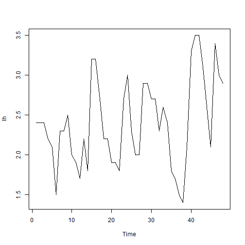

```r
plot(lh)
```

# 模拟2

- acf与pacf：自己相关系数与偏自己相关系数

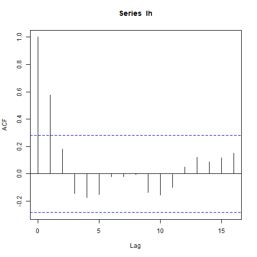

```r
acf(lh)
```

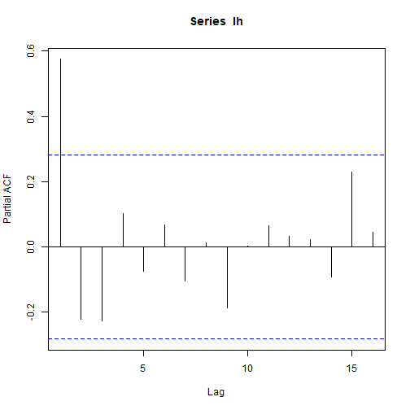

```r
pacf(lh)
```

# 模拟3

```r
lh.ar = ar(lh,aic=T)
lh.ar
```

```
##
## Call:
## ar(x = lh, aic = T)
##
## Coefficients:
##       1        2        3
##  0.6534  -0.0636  -0.2269
##
## Order selected 3  sigma^2 estimated as  0.1959
```

- 推定式子：
`$$\hat{y}_{t}=0.653y_{t-1}-0.063y_{t-2}-0.227y_{t-3}$$`

# 残差项的自己相关check

- install.packages("forecast")

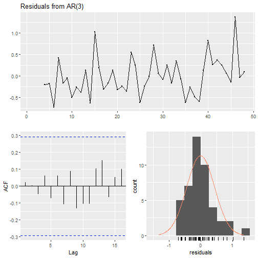

```r
library(forecast)
checkresiduals(lh.ar)
```

# AR model的预测1

- 函数predict 我们来预测到第10期的数据

```r
 lh.pr=predict(lh.ar,n.ahead=10)
 lh.pr
```

```
## $pred
## Time Series:
## Start = 49
## End = 58
## Frequency = 1
##  [1] 2.461588 2.272267 2.199151 2.262914 2.352194 2.423066
##  [7] 2.449223 2.441544 2.418779 2.398456
##
## $se
## Time Series:
## Start = 49
## End = 58
## Frequency = 1
##  [1] 0.4425687 0.5286675 0.5525786 0.5527502 0.5592254
##  [6] 0.5665903 0.5688786 0.5689385 0.5692396 0.5697534
```

# AR model的预测2

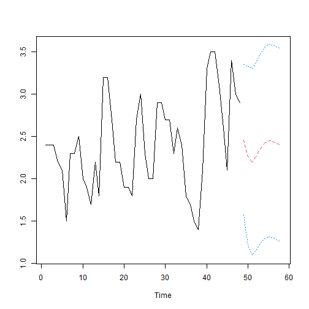

```r
lh.SE1<-lh.pr$pred+2*lh.pr$se
lh.SE2<-lh.pr$pred-2*lh.pr$se
ts.plot(lh,lh.pr$pred,lh.SE1,lh.SE2,gpars=list(lt=c(1,2,3,3),col=c(1,2,4,4)))
```

# 补充

- 用最小二乘法来推定

```r
lh.ar2=ar(lh,aic=T,method="ols")
lh.ar2
```

```
##
## Call:
## ar(x = lh, aic = T, method = "ols")
##
## Coefficients:
##     1
## 0.586
##
## Intercept: 0.006234 (0.06551)
##
## Order selected 1  sigma^2 estimated as  0.2016
```

# ARIMA model

- ARMA model 自回归-滑动平均混合模型

`$$y_{t}=c+\varepsilon_{t}+\sum_{i=1}^{p}\phi_{i}y_{t-i}+\sum_{i=1}^{q}\theta_{i}\varepsilon_{t-i}$$`
 - p次AR model+q次MA model
- +d阶差分： ARIMA（p，d，q）
`$$y_{t}-y_{t-d}=c+\varepsilon_{t}+\sum_{i=1}^{p}\phi_{i}y_{t-i}+\sum_{i=1}^{q}\theta_{i}\varepsilon_{t-i}$$`

- Autoregressive Integrated Moving Average model 差和整合移动平均回归模型

# ARIMA模拟1

```r
auto.arima(lh,ic="aic",stepwise=T, trace=T)
```

- stepwise=T: 逐步选择
 - trace=T: ARIMA模型列表

```
##
##  ARIMA(2,0,2) with non-zero mean : 66.42642
##  ARIMA(0,0,0) with non-zero mean : 82.09291
##  ARIMA(1,0,0) with non-zero mean : 64.75832
##  ARIMA(0,0,1) with non-zero mean : 68.10389
##  ARIMA(0,0,0) with zero mean     : 224.6837
##  ARIMA(2,0,0) with non-zero mean : 64.50375
##  ARIMA(3,0,0) with non-zero mean : 64.18482
##  ARIMA(4,0,0) with non-zero mean : 65.84091
##  ARIMA(3,0,1) with non-zero mean : 64.47047
##  ARIMA(2,0,1) with non-zero mean : 65.20321
##  ARIMA(4,0,1) with non-zero mean : 66.41819
##  ARIMA(3,0,0) with zero mean     : 80.68744
##
##  Best model: ARIMA(3,0,0) with non-zero mean
```

```
## Series: lh
## ARIMA(3,0,0) with non-zero mean
##
## Coefficients:
##          ar1      ar2      ar3    mean
##       0.6448  -0.0634  -0.2198  2.3931
## s.e.  0.1394   0.1668   0.1421  0.0963
##
## sigma^2 estimated as 0.1949:  log likelihood=-27.09
## AIC=64.18   AICc=65.61   BIC=73.54
```

# 模拟练习

- 用ARIMA来预测10年左右的数据并和原数据画图比较。
 - 注意：根据刚刚得出的pdq先得出推测公式
  arima(lh,order=c(3,0,0))

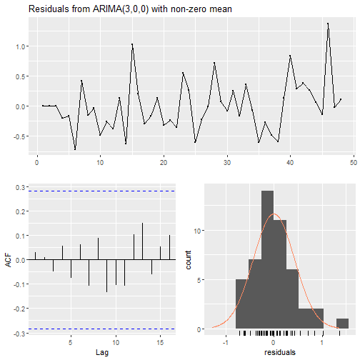

```
##
## 	Ljung-Box test
##
## data:  Residuals from ARIMA(3,0,0) with non-zero mean
## Q* = 3.8591, df = 6, p-value = 0.6957
##
## Model df: 4.   Total lags used: 10
```

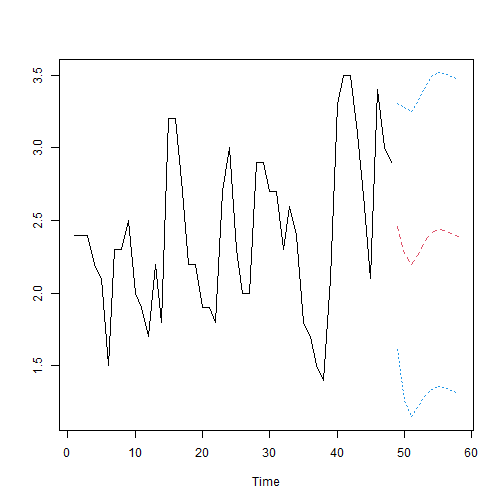

# 总结

- AR model  自己回归
- MA model  移动平均
- ARMA model 自己回归移动平均
- ARIMA model 自己回归和分移动平均
- 用函数auto.arima选择最优的p，d，q